# Week 4 - Univariate Analysis, part 2

# TABLE OF CONTENT

- JUMP TO Q2 - ANSWERS
  - [Dataset 1 - EDA]
- JUMP TO Q4 - ANSWERS

# 1. Lesson - None

# 2. Weekly graph question

Below are a histogram and boxplot representation of the same data. A pharmacy is keeping a record of the prices of the drugs that it sells, and an administrator wants to know how much the more expensive drugs tend to cost, in the context of the other prices.

Please write a short explanation of the pros and cons of these two representations. Which would you choose? How would you modify the formatting, if at all, to make it more visually interesting, clear, or informative?

```python
import numpy as np
import pandas as pd

np.random.seed(0)
num_data = 100
data = np.exp(np.random.uniform(size = num_data) * 4)
df = pd.DataFrame(data.T, columns = ["data"])
```

```
The 75th percentile is: data    15.457656
Name: 0.75, dtype: float64
```

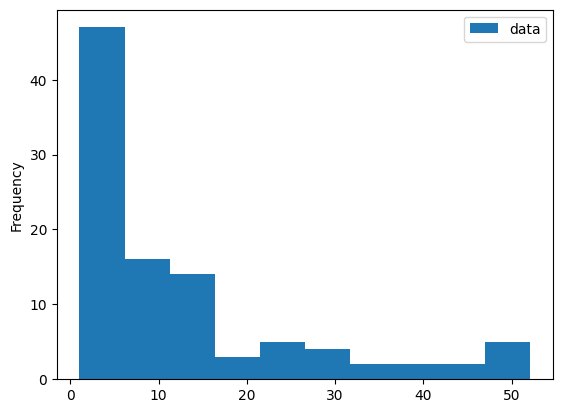

```python
print("The 75th percentile is:", df.quantile(q = 0.75))
df.plot.hist()
```

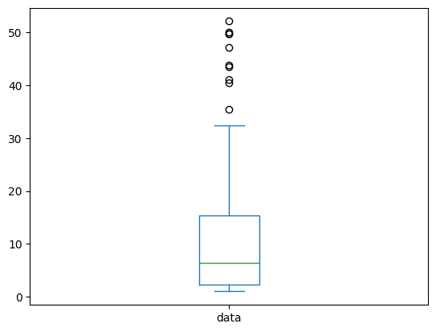

```python
df.plot.box()
```

### **answer**

Between boxplot and histogram, boxplot gives more statistical information such as the median line, the quartiles, and the extreme values. Histogram mostly gives the spread and the count of each event. However, boxplot may be preferred on academic research or people involved in statistics. Thus, histogram is usually used in most cases as more readers (or lay persons) can easily digest or understand the graph. To make it more interesting, we can always add median line, or color the extreme values in the histogram to give similar information as a boxplot.

# 3. Homework - working on your datasets

This week, you will do the same types of exercises as last week, but you should use your chosen datasets that someone in your class found last semester. (They likely will not be the particular datasets that you found yourself.)

### Here are some types of analysis you can do:

- Draw histograms and histogram variants for each feature or column. (Swarm plot, kde plot, violin plot).
- Draw grouped histograms. For instance, if you have tree heights for both maple and oak trees, you could draw histograms for both.
- Draw a bar plot to indicate total counts of each categorical variable in a given column.
- Find means, medians, and modes.

### Conclusions:

- Explain what conclusions you would draw from this analysis: are the data what you expect? Are the data likely to be usable? If they are not useable, find some new data!
- What is the overall shape of the distribution? Is it normal, skewed, bimodal, uniform, etc.?
- Are there any outliers present? (Data points that are far from the others.)
- If there are multiple related histograms, how does the distribution change across different groups?
- What are the minimum and maximum values represented in each histogram?
- How do bin sizes affect the histogram? Does changing the bin width reveal different patterns in the data?
- Does the distribution appear normal, or does it have a different distribution?

```
    ----        ----        ----
```

### *ANSWER*

#### DATA IMPORT -------------

```python
import pandas as pd
import numpy as np
import openpyxl
from datetime import datetime, timedelta
import matplotlib.pyplot as plt
import seaborn as sns
from scipy import stats
from plotnine import *
```

```python
#### DATASET1 = MIMIC dataset

df1 = pd.read_csv('dataset - acute kidney injury in MIMIC.csv')


#### DATASET2 = chronic kidney

df2 = pd.read_csv('chronic_kidney_disease_prepared.csv')


#### DATASET3

df3 = pd.read_excel('Diabetic_Nephropathy_v1.xlsx')
```

```python
###### templated functions

####### >> Summary stats
def step1(df, info):
    """
    Summ stats for numerical columns in a DataFrame.
    """


    print("=" * 50)
    # print(f" - - - {info.upper()} - - - -")
    print(f"\033[2;33;47m{"-" *47} \n-- - - - {info.upper()} - - ----\n{"-" *47} \033[0m")  # yellow font, grey background
    print("___________comparison of numerical columns___________")
    print("=" * 50)

     # 1. overview
    ## selection
    df_a = df.select_dtypes(include='number')

    df_summary = pd.DataFrame({
    'Mean': df_a.mean(),
    'Median': df_a.median(),
    'Mode': df_a.apply(lambda x: stats.mode(x, keepdims=True).mode[0])  # Fixed mode application
})

    print(df_summary.round(3))

#-----------------------------------------------------------------------------------------


####### >> Basic histogram

def step2_numerics(df, columns, bins=30, figsize=(4,2)):
    """
    Generate several histograms for selected cols.

    Parameters:
    df (pd.DataFrame): The dataset.
    columns (list): List of column names to plot histograms for.
    bins (int): Number of bins for histograms (default=30).
    figsize (tuple): Figure size (default=(8, 4)).

    """
    for col in columns:
        plt.figure(figsize=figsize)
        sns.histplot(df[col], bins=bins, kde=True, edgecolor="black",  shrink=0.5)

        # Formatting
        plt.title(f"Histogram of {col}", fontsize=11, fontweight="bold")
        plt.xlabel(col)
        plt.ylabel("Frequency")
        plt.grid(axis='y', linestyle='--', alpha=0.5)

        plt.show()


def step2_discrete(df, columns, figsize=(4,2)):
    """
    Generate several histograms for selected cols.

    Parameters:
    df (pd.DataFrame): The dataset.
    columns (list): List of column names to plot histograms for.
    bins (int): Number of bins for histograms (default=30).
    figsize (tuple): Figure size (default=(8, 4)).

    """
    for col in columns:
        plt.figure(figsize=figsize)
        sns.histplot(df, x =col, discrete=True, edgecolor="black",  shrink=0.5)

        # Formatting
        plt.title(f"Histogram of {col}", fontsize=11, fontweight="bold")
        plt.xlabel(col)
        plt.xticks(sorted(df[col].unique()))

        plt.ylabel("Frequency")
        plt.grid(axis='y', linestyle='--', alpha=0.5)

        plt.show()

#-----------------------------------------------------------------------------------------
```

#### WORK -------------

##### DATASET 1 _______

- Consist 57 columns
- some important colums are:
  - aki_stage = state of acute kidney disease
  - anemia = presence of anemia (0 or 1)

**chosen features:** The dataset is large. In order to save times, I selected several columns that may show some correlations and frequently used in medical research.

```
___ EDA
```

**review of some variables**

```python
step1(df1, "MIMIC dataset - acute kidney injury")
```

```
==================================================
-----------------------------------------------
-- - - - MIMIC DATASET - ACUTE KIDNEY INJURY - - ----
-----------------------------------------------
___________comparison of numerical columns___________
==================================================
                   Mean   Median   Mode
age              65.109    67.00   91.0
bmi              29.305    27.70    NaN
weight           83.748    80.00    NaN
t                36.897    36.90   36.6
p                88.262    87.00   84.0
r                19.815    19.00   18.0
bp               77.421    76.00   74.0
vent_firstday     0.609     1.00    1.0
vaso_firstday     0.386     0.00    0.0
chf               0.220     0.00    0.0
ckd               0.141     0.00    0.0
liver             0.079     0.00    0.0
pulmonary         0.202     0.00    0.0
hypertension      0.119     0.00    0.0
malignancy        0.161     0.00    0.0
stroke            0.090     0.00    0.0
cad               0.255     0.00    0.0
diabetes          0.282     0.00    0.0
hiv               0.003     0.00    0.0
anemia            0.228     0.00    0.0
drug_abuse        0.038     0.00    0.0
alcohol_abuse     0.085     0.00    0.0
sepsis            0.668     1.00    1.0
aki_stage         2.075     2.00    2.0
sofa              5.551     5.00    4.0
sapsii           41.073    40.00   37.0
mort_28_day       0.211     0.00    0.0
mort_90_day       0.288     0.00    0.0
mort_1_year       0.375     0.00    0.0
cox_los          70.888    91.00   91.0
sii            2790.031  1955.00  370.0
plr             261.465   200.00  104.0
nlr              12.562    10.00    5.0
mlr               0.479     0.00    0.0
glucose         158.346   137.00  118.0
wbc              13.436    12.20    8.0
rbc               3.635     3.59    3.6
ne               81.317    83.60   87.0
ly               10.161     8.70    4.0
mn                4.200     3.90    3.0
rdw              15.144    14.70   14.2
hb               10.960    10.80   10.7
plt             219.060   204.00  199.0
ck             1044.841    60.00    NaN
ph                7.354     7.37    NaN
cl              105.126   105.00  105.0
na              138.402   138.00  139.0
k                 4.222     4.10    3.8
bicarbonate      22.814    23.00   23.0
scr               1.548     1.10    0.8
bun              31.396    23.00   17.0
po2             171.746   125.00    NaN
pco2             42.234    40.00    NaN
lactate           2.569     1.90    NaN
```

___visualizations of select individual columns__

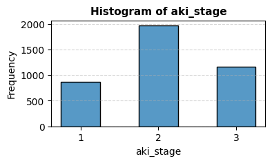

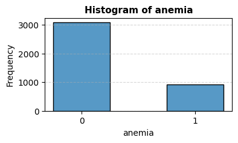

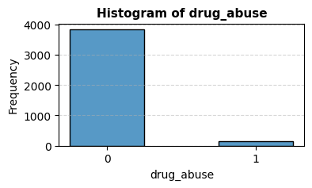

```python
step2_discrete(df1, ['aki_stage', 'anemia', 'drug_abuse'])
```

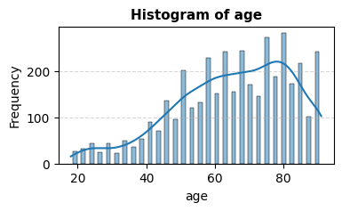

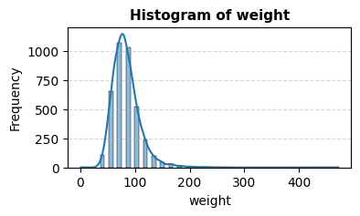

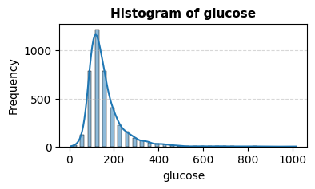

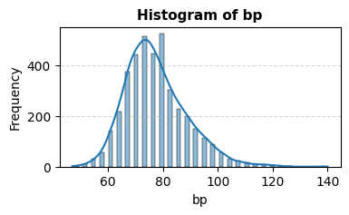

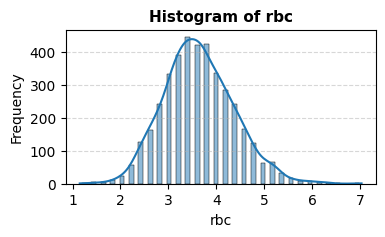

```python
step2_numerics(df1, ['age', 'weight', 'glucose', 'bp', 'rbc'])
```

___visualization of some correlated columns (or possible research questions)__

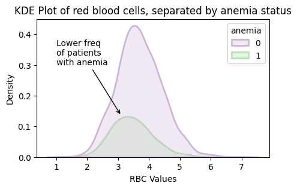

```python
plt.figure(figsize=(5,3))
sns.kdeplot(data=df1, x='rbc', hue='anemia', fill=True, alpha=0.3, linewidth=2, palette='PRGn')

plt.title("KDE Plot of red blood cells, separated by anemia status")
plt.xlabel("RBC Values")
plt.ylabel("Density")
plt.annotate("Lower freq \nof patients \nwith anemia", xy=(3.1, .135), xytext=(1, .3),
             arrowprops=dict(arrowstyle="->", color="black", lw=1),
             fontsize=10, color="black")
plt.show()
```

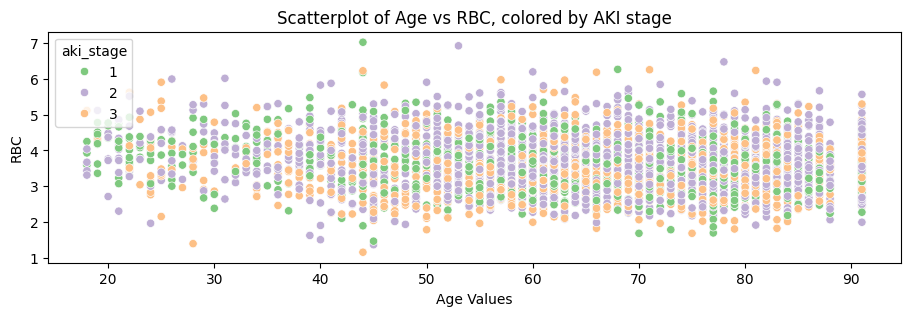

```python
plt.figure(figsize=(11,3))
sns.scatterplot(data=df1, x='age', y='rbc', hue='aki_stage',  palette='Accent')

plt.title("Scatterplot of Age vs RBC, colored by AKI stage")
plt.xlabel("Age Values")
plt.ylabel("RBC")
# plt.annotate("AKI stage does not show any association with age or RBC levels"
#     , xy=(5, 10)
#     , xytext=(21, 7)
#     , arrowprops=dict(arrowstyle="->", color="black", lw=1)
#     ,fontsize=10, color="black")
plt.show()
```

# 4. Storytelling With Data graph

Reproduce any graph of your choice in p. 52-68 of the Storytelling With Data book as best you can. (The second half of chapter two). You do not have to get the exact data values right, just the overall look and feel.

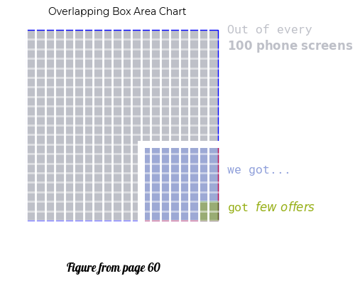

```python
import matplotlib.patches as patches

from pyfonts import load_google_font

# Making figure in page 60


fig, ax = plt.subplots(figsize=(4, 4))
font1 = load_google_font("Lobster")
font2 = load_google_font("Montserrat")
font3 = load_google_font("Roboto Mono")

##_ boxes
rect1 = patches.Rectangle((0, 0), 20, 20, edgecolor='blue', facecolor='#BEC0C8')

rect2 = patches.Rectangle((12, 0), 8, 8, edgecolor='red', facecolor='#90A0DB', alpha=0.7)

rect3 = patches.Rectangle((18, 0), 2,2, edgecolor='green', facecolor='#96AF15', alpha=0.5)

# Add rectangles to plot
ax.add_patch(rect1)
ax.add_patch(rect2)
ax.add_patch(rect3)

# Set limits and labels
ax.set_xlim(-2, 21)
ax.set_ylim(-2, 21)
ax.set_xlabel("")
ax.set_ylabel("")
ax.set_title("Overlapping Box Area Chart", font=font2)

plt.gca().axes.set_frame_on(False)  #axis frame
# plt.xticks([])
# plt.yticks([])
# plt.gca().axes.get_xaxis().set_visible(False)
# plt.gca().axes.get_yaxis().set_visible(False)

plt.xticks(np.arange(-2, 20, 1), [])
plt.yticks(np.arange(-2, 20, 1), [])
plt.tick_params(axis='x', length=0, width=0)
plt.tick_params(axis='y', length=0, width=0)


# plt.gca().spines["bottom"].set_visible(False)
# plt.tick_params(axis="x", direction="inout", length=8, width=2, colors="black")  # Adjusts ticks

plt.grid(axis='x', linestyle='-', color='white', linewidth = 2)
plt.grid(axis='y', linestyle='-', color = 'white', linewidth = 2, alpha=0.5)

plt.plot([12, 12], [0, 8], color='white', linewidth=7.2)  # drawing separation line
plt.plot([12, 20], [8, 8], color='white', linewidth=7.2)


plt.annotate("Out of every\n" + r"$\bf{ 100\  phone\  screens}$",
             xy=(5, 10),
             xytext=(21, 18),
             fontsize=12,
             color="#BEC0C8"
             ,font=font3
             )


plt.annotate(r"we got...",
             xy=(5, 10),
             xytext=(21, 5),
             fontsize=12,
             color="#90A0DB",font=font3
             )


plt.annotate("got " + r"$\it{few\ offers}$",
             xy=(5, 10),
             xytext=(21,1),
             fontsize=12,
             color="#96AF15",font=font3
             )




plt.figtext(0.5, 0, "Figure from page 60", ha="center", fontsize=12, fontstyle="italic", font=font1)

# Show plot
plt.grid(True)
plt.show()
```